# EDA & MODELLING_GRP10

### Hypothesis Testing

- Null Hypothesis (H₀): There is no significant difference in the average monetary value across different customer segments (rf_category).
- Alternative Hypothesis (H₁): There is a significant difference in the average monetary value across different customer segments (rf_category).

```python
# Grouping the data by rf_category
groups = [rfm[rfm['rf_category'] == category]['monetary'] for category in rfm['rf_category'].unique()]

# Conducting ANOVA
f_statistic, p_value = stats.f_oneway(*groups)

print(f"F-statistic: {f_statistic}")
print(f"P-value: {p_value}")

# Interpreting the results
if p_value < 0.05:
    print("Reject the null hypothesis: Significant difference in average monetary value between customer segments.")
else:
    print("Fail to reject the null hypothesis: No significant difference in average monetary value between customer segments.")
```

```
F-statistic: 7.620268363851451
P-value: 3.397577779364622e-11
Reject the null hypothesis: Significant difference in average monetary value between customer segments.
```

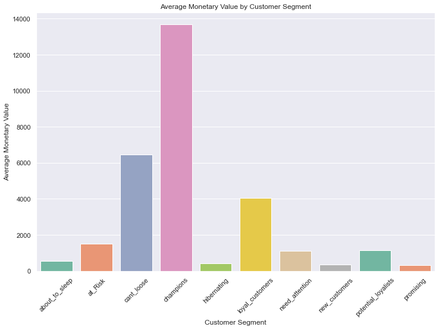

```python
# Calculate the average monetary value for each customer segment
avg_monetary_by_segment = rfm.groupby('rf_category')['monetary'].mean().reset_index()

# Set the figure size for the plot
plt.figure(figsize=(12, 8))

# Create a bar plot for average monetary value across different customer segments
sns.barplot(x='rf_category', y='monetary', data=avg_monetary_by_segment, palette='Set2')

# Set the title and labels
plt.title('Average Monetary Value by Customer Segment')
plt.xlabel('Customer Segment')
plt.ylabel('Average Monetary Value')

# Rotate the x-axis labels for better readability if needed
plt.xticks(rotation=45)

# Show the plot
plt.show()
```

### Merging the CLTV and RFM datasets

```python
# Resetting the index for the RFM dataset since 'customer id' is an index
rfm.reset_index(inplace=True)

# Merging 'recency' and 'frequency' columns from RFM into CLTV based on 'customer id'
merged_df = pd.merge(cltv, rfm[['customer id', 'recency', 'frequency']], on='customer id', how='left')

# Display the merged dataframe
merged_df.head()
```

|  | customer id | total_transaction | total_unit | total_price | average_order_value | purchase_frequency | customer_value | profit_margin | cltv | recency | frequency |
| --- | --- | --- | --- | --- | --- | --- | --- | --- | --- | --- | --- |
| 0 | 12346.000000 | 12 | 74285 | 77556.460000 | 6463.038333 | 0.002041 | 13.191061 | 7755.646000 | 370580.578319 | 329.000000 | 7.000000 |
| 1 | 12347.000000 | 8 | 2967 | 4921.530000 | 615.191250 | 0.001361 | 0.837275 | 492.153000 | 1492.634076 | 6.000000 | 8.000000 |
| 2 | 12348.000000 | 5 | 2714 | 2019.400000 | 403.880000 | 0.000850 | 0.343298 | 201.940000 | 251.118417 | 79.000000 | 5.000000 |
| 3 | 12349.000000 | 4 | 1624 | 4428.690000 | 1107.172500 | 0.000680 | 0.752877 | 442.869000 | 1207.770520 | 22.000000 | 4.000000 |
| 4 | 12350.000000 | 1 | 197 | 334.400000 | 334.400000 | 0.000170 | 0.056848 | 33.440000 | 6.885990 | 314.000000 | 1.000000 |

### Outlier Detection and Treatment on the merged dataset

#### Outlier calculation using z-score

```python
# List of columns for analysis
columns = ['total_transaction', 'total_unit', 'total_price', 'average_order_value',
           'purchase_frequency', 'customer_value', 'profit_margin', 'cltv',
           'recency', 'frequency']

# Calculate Z-scores for the dataset
z_scores = np.abs(stats.zscore(merged_df[columns]))

# Define a threshold for Z-scores (commonly 3)
z_threshold = 3

# Calculate the percentage of outliers for each column
z_outliers_percentage = (z_scores > z_threshold).mean(axis=0) * 100
print("Z-score method: Percentage of outliers for each column:")
print(z_outliers_percentage)

# Calculate the total percentage of outliers across all columns
z_total_outliers = (z_scores > z_threshold).sum(axis=1) > 0
z_total_percentage = (z_total_outliers.sum() / len(merged_df)) * 100
print(f'Total percentage of outliers using Z-score: {z_total_percentage:.2f}%')
```

```
Z-score method: Percentage of outliers for each column:
total_transaction     0.204116
total_unit            0.544310
total_price           0.187107
average_order_value   0.323184
purchase_frequency    0.204116
customer_value        0.187107
profit_margin         0.187107
cltv                  0.017010
recency               0.000000
frequency             0.000000
dtype: float64
Total percentage of outliers using Z-score: 0.83%
```

#### Outlier calculation using IQR

```python
# Calculate IQR for each column
Q1 = merged_df[columns].quantile(0.25)
Q3 = merged_df[columns].quantile(0.75)
IQR = Q3 - Q1

# Define the lower and upper bounds
lower_bound = Q1 - 1.5 * IQR
upper_bound = Q3 + 1.5 * IQR

# Calculate the percentage of outliers for each column based on IQR
iqr_outliers_percentage = ((merged_df[columns] < lower_bound) | (merged_df[columns] > upper_bound)).mean(axis=0) * 100
print("IQR method: Percentage of outliers for each column:")
print(iqr_outliers_percentage)

# Calculate the total percentage of outliers across all columns
iqr_total_outliers = ((merged_df[columns] < lower_bound) | (merged_df[columns] > upper_bound)).sum(axis=1) > 0
iqr_total_percentage = (iqr_total_outliers.sum() / len(merged_df)) * 100
print(f'Total percentage of outliers using IQR: {iqr_total_percentage:.2f}%')
```

```
IQR method: Percentage of outliers for each column:
total_transaction      7.280150
total_unit            10.273856
total_price           10.784147
average_order_value    6.599762
purchase_frequency     7.280150
customer_value        10.784147
profit_margin         10.784147
cltv                  16.397346
recency                0.000000
frequency              6.718830
dtype: float64
Total percentage of outliers using IQR: 20.11%
```

#### Choosing best method for outlier treatment

```python
# Compare total percentages
if z_total_percentage < iqr_total_percentage:
    print("Z-score method detects a lower percentage of outliers.")
    method = 'Z-score'
    treated_df = merged_df[~z_total_outliers]  # Filter out Z-score outliers
else:
    print("IQR method detects a lower percentage of outliers.")
    method = 'IQR'
    treated_df = merged_df[~iqr_total_outliers]  # Filter out IQR outliers

# Display the method chosen and the treated dataframe
print(f'Outlier treatment method chosen: {method}')
print(f'Treated dataset shape: {treated_df.shape}')
```

```
Z-score method detects a lower percentage of outliers.
Outlier treatment method chosen: Z-score
Treated dataset shape: (5830, 11)
```

### Feature selection and Modelling

```python
# Installing the XGBoost package, used for gradient boosting.
!pip install xgboost

# Handles missing data by imputing values.
from sklearn.impute import SimpleImputer

# Feature selection based on statistical tests.
from sklearn.feature_selection import SelectKBest, f_regression

# Splits data into training and testing sets.
from sklearn.model_selection import train_test_split

# Ensemble models for regression tasks.
from sklearn.ensemble import RandomForestRegressor, GradientBoostingRegressor

# Implements linear regression model.
from sklearn.linear_model import LinearRegression

# Regression using decision trees.
from sklearn.tree import DecisionTreeRegressor

# K-nearest neighbors algorithm for regression.
from sklearn.neighbors import KNeighborsRegressor

# Metrics for evaluating regression models.
from sklearn.metrics import r2_score, mean_absolute_error, mean_squared_error

# XGBoost algorithm for boosting trees, often used in regression and classification.
import xgboost as xgb

# For hyperparameter tuning.
from sklearn.model_selection import GridSearchCV
```

```python
#printing the head of the merged_df
merged_df.head()
```

|  | customer id | total_transaction | total_unit | total_price | average_order_value | purchase_frequency | customer_value | profit_margin | cltv | recency | frequency |
| --- | --- | --- | --- | --- | --- | --- | --- | --- | --- | --- | --- |
| 0 | 12346.000000 | 12 | 74285 | 77556.460000 | 6463.038333 | 0.002041 | 13.191061 | 7755.646000 | 370580.578319 | 329.000000 | 7.000000 |
| 1 | 12347.000000 | 8 | 2967 | 4921.530000 | 615.191250 | 0.001361 | 0.837275 | 492.153000 | 1492.634076 | 6.000000 | 8.000000 |
| 2 | 12348.000000 | 5 | 2714 | 2019.400000 | 403.880000 | 0.000850 | 0.343298 | 201.940000 | 251.118417 | 79.000000 | 5.000000 |
| 3 | 12349.000000 | 4 | 1624 | 4428.690000 | 1107.172500 | 0.000680 | 0.752877 | 442.869000 | 1207.770520 | 22.000000 | 4.000000 |
| 4 | 12350.000000 | 1 | 197 | 334.400000 | 334.400000 | 0.000170 | 0.056848 | 33.440000 | 6.885990 | 314.000000 | 1.000000 |

#### Step 1: Handle Missing Values

```python
# Define feature columns and target variable
feature_cols = ['total_transaction', 'total_unit', 'total_price', 'average_order_value',
                'purchase_frequency', 'customer_value', 'profit_margin', 'recency', 'frequency']
X = merged_df[feature_cols]
y = merged_df['cltv']
```

```python
# Impute missing values with the mean for simplicity
imputer = SimpleImputer(strategy='mean')
X_imputed = imputer.fit_transform(X)
```

#### Step 2: Feature Selection

```python
# Select top k features using SelectKBest with f_regression
k = 5  # Number of top features you want
selector = SelectKBest(score_func=f_regression, k=k)
X_selected = selector.fit_transform(X_imputed, y)
```

We have used regression to perform feature selection since it renders the relative feature importance in terms of statistical coefficients, whereas other tree methods like random forest measure feature importance through metrics like Gini impurity or information gain, which are more complex to interpret.

```python
# Get selected feature names
selected_features = X.columns[selector.get_support()]
print("\nSelected Features based on SelectKBest:")
print(selected_features.tolist())
```

```
Selected Features based on SelectKBest:
['total_transaction', 'total_price', 'purchase_frequency', 'customer_value', 'frequency']
```

```python
# Create a new DataFrame with the selected features and target variable
selected_df = pd.DataFrame(X_selected, columns=selected_features)
selected_df['cltv'] = y.values
```

```python
# Display the selected_df
print("\nDataset after Feature Selection:")
selected_df.head()
```

```
Dataset after Feature Selection:
```

|  | total_transaction | total_price | purchase_frequency | customer_value | frequency | cltv |
| --- | --- | --- | --- | --- | --- | --- |
| 0 | 12.000000 | 77556.460000 | 0.002041 | 13.191061 | 7.000000 | 370580.578319 |
| 1 | 8.000000 | 4921.530000 | 0.001361 | 0.837275 | 8.000000 | 1492.634076 |
| 2 | 5.000000 | 2019.400000 | 0.000850 | 0.343298 | 5.000000 | 251.118417 |
| 3 | 4.000000 | 4428.690000 | 0.000680 | 0.752877 | 4.000000 | 1207.770520 |
| 4 | 1.000000 | 334.400000 | 0.000170 | 0.056848 | 1.000000 | 6.885990 |

#### Step 3: Train-Test Split

```python
# Split the data into training and testing sets (80% train, 20% test)
X_train, X_test, y_train, y_test = train_test_split(X_selected, y, test_size=0.2, random_state=42)
```

#### Step 4: Model Training and Evaluation

#### Models Applied: -

##### Linear Regression:

Linear Regression is a supervised learning algorithm used to predict continuous values. It assumes a linear relationship between the input features (e.g., purchase frequency, average order value) and the target variable (CLTV). The goal is to find the best-fitting line through the data points, minimizing the difference between the predicted and actual values.

##### Decision Tree:

A Decision Tree is a non-linear model that splits the data into subsets based on feature values to make predictions. It starts with a root node and branches into sub-nodes based on conditions that best separate the data. Decision trees can handle both categorical and continuous data and provide intuitive, visual representations of decision-making processes. However, they tend to overfit the training data, especially if the tree is deep, leading to poor generalization on new data. Pruning methods can be applied to prevent overfitting.

##### Random Forest:

Random Forest is an ensemble learning technique that builds multiple Decision Trees (called "weak learners") and aggregates their predictions to make a final decision. It reduces overfitting by creating trees from random samples of data and random subsets of features at each split.

##### K-Nearest Neighbour:

KNN is a non-parametric, instance-based learning algorithm used for classification and regression tasks. It makes predictions by finding the 'k' nearest data points (neighbors) to the query point and taking a majority vote (classification) or averaging the values (regression).

##### Gradient boosting:

Gradient Boosting is an ensemble machine learning technique used for both regression andclassification tasks. It builds models sequentially, where each new model corrects the errors of the previous models. This process is based on the principle of boosting, which means combining the strengths of weak learners (typically decision trees) to create a stronger, more accurate model.XGBoost and LightGBM are popular implementations that improve speed and accuracy.

```python
# Initialize models for comparison
models = {
    'Linear Regression': LinearRegression(),
    'Decision Tree': DecisionTreeRegressor(random_state=42),
    'Random Forest': RandomForestRegressor(random_state=42),
    'K-Nearest Neighbors': KNeighborsRegressor(),
    'Gradient Boosting': GradientBoostingRegressor(random_state=42),
    'XGBoost': xgb.XGBRegressor(random_state=42)
}
```

```python
# Dictionary to store scores
scores = {
    'R² Score': {},
    'MAE': {},
    'MSE': {},
    'RMSE': {},
    'Adjusted R² Score': {}
}
```

```python
# Train and evaluate each model
for name, model in models.items():
    model.fit(X_train, y_train)  # Train the model
    y_pred = model.predict(X_test)  # Make predictions

    # Calculate scores
    r2 = r2_score(y_test, y_pred)
    mae = mean_absolute_error(y_test, y_pred)
    mse = mean_squared_error(y_test, y_pred)
    rmse = np.sqrt(mse)

    # Calculate Adjusted R² Score
    n = X_test.shape[0]  # Number of samples
    p = X_test.shape[1]  # Number of features
    adj_r2 = 1 - (1 - r2) * (n - 1) / (n - p - 1)

    # Store scores
    scores['R² Score'][name] = r2
    scores['MAE'][name] = mae
    scores['MSE'][name] = mse
    scores['RMSE'][name] = rmse
    scores['Adjusted R² Score'][name] = adj_r2

    print(f'\n{name} Scores:')
    print(f'R² Score: {r2:.4f}')
    print(f'MAE: {mae:.4f}')
    print(f'MSE: {mse:.4f}')
    print(f'RMSE: {rmse:.4f}')
    print(f'Adjusted R² Score: {adj_r2:.4f}')
```

```
Linear Regression Scores:
R² Score: -23.5142
MAE: 796029.2169
MSE: 7302417040864.9736
RMSE: 2702298.4737
Adjusted R² Score: -23.6190

Decision Tree Scores:
R² Score: 0.9540
MAE: 5837.3406
MSE: 13691165216.3434
RMSE: 117009.2527
Adjusted R² Score: 0.9538

Random Forest Scores:
R² Score: 0.9494
MAE: 6211.6992
MSE: 15084631825.2854
RMSE: 122819.5091
Adjusted R² Score: 0.9491

K-Nearest Neighbors Scores:
R² Score: 0.6250
MAE: 13671.2164
MSE: 111697418550.0006
RMSE: 334211.6374
Adjusted R² Score: 0.6234

Gradient Boosting Scores:
R² Score: 0.9539
MAE: 5428.5091
MSE: 13739121114.5096
RMSE: 117213.9971
Adjusted R² Score: 0.9537

XGBoost Scores:
R² Score: 0.8503
MAE: 13183.5821
MSE: 44593236481.9084
RMSE: 211171.1071
Adjusted R² Score: 0.8497
```

#### Model Comparison: Detailed Insights and Analysis

##### Overview

This document provides a comprehensive comparison of various regression models based on their performance metrics. We evaluate the models using R² Score, MAE, MSE, RMSE, and Adjusted R² Score to determine which model best fits the data and why.

##### R² Score

- **Excellent**: R² Score ≥ 0.90
  - The model explains 90% or more of the variance, indicating a very good fit.
- **Good**: 0.70 ≤ R² Score < 0.90
  - The model explains between 70% and 89% of the variance, showing a good fit.
- **Fair**: 0.50 ≤ R² Score < 0.70
  - The model explains between 50% and 69% of the variance, indicating a moderate fit.
- **Poor**: R² Score < 0.50
  - The model explains less than 50% of the variance, indicating a poor fit.

##### MAE (Mean Absolute Error)

**MAE** measures the average magnitude of prediction errors. Lower values indicate better model accuracy.

- **Excellent**: MAE < 5000
  - The model’s average error is very low, indicating high accuracy.
- **Good**: 5000 ≤ MAE < 10000
  - The model’s average error is relatively low, showing good accuracy.
- **Fair**: 10000 ≤ MAE < 20000
  - The model’s average error is moderate, indicating fair accuracy.
- **Poor**: MAE ≥ 20000
  - The model’s average error is high, indicating poor accuracy.

##### MSE (Mean Squared Error)

**MSE** measures the average of the squares of the errors. Lower values are preferred as MSE penalizes larger errors more heavily.

- **Excellent**: MSE < 1,000,000,000
  - The model’s average squared error is very low, indicating high accuracy.
- **Good**: 1,000,000,000 ≤ MSE < 10,000,000,000
  - The model’s average squared error is relatively low, showing good accuracy.
- **Fair**: 10,000,000,000 ≤ MSE < 100,000,000,000
  - The model’s average squared error is moderate, indicating fair accuracy.
- **Poor**: MSE ≥ 100,000,000,000
  - The model’s average squared error is high, indicating poor accuracy.

##### RMSE (Root Mean Squared Error)

**RMSE** provides the square root of MSE, giving an error magnitude in the same units as the target variable. Lower values are preferred.

- **Excellent**: RMSE < 10,000
  - The model’s root mean squared error is very low, indicating high accuracy.
- **Good**: 10,000 ≤ RMSE < 20,000
  - The model’s root mean squared error is relatively low, showing good accuracy.
- **Fair**: 20,000 ≤ RMSE < 50,000
  - The model’s root mean squared error is moderate, indicating fair accuracy.
- **Poor**: RMSE ≥ 50,000
  - The model’s root mean squared error is high, indicating poor accuracy.

##### Adjusted R² Score

The **Adjusted R² Score** adjusts the R² Score for the number of predictors, providing a more accurate measure of model fit. Higher values are better.

- **Excellent**: Adjusted R² Score ≥ 0.90
  - The model’s fit is very good, considering the number of predictors.
- **Good**: 0.70 ≤ Adjusted R² Score < 0.90
  - The model’s fit is good, considering the number of predictors.
- **Fair**: 0.50 ≤ Adjusted R² Score < 0.70
  - The model’s fit is moderate, considering the number of predictors.
- **Poor**: Adjusted R² Score < 0.50
  - The model’s fit is poor, considering the number of predictors.

##### Model Performance and Insights

##### Random Forest

- **R² Score**: 0.9494
- **MAE**: 6211.6992
- **MSE**: 15084631825.2854
- **RMSE**: 122819.5091
- **Adjusted R² Score**: 0.9491

##### Linear Regression

- **R² Score**: -23.5142
- **MAE**: 796029.2169
- **MSE**: 7302417040864.9736
- **RMSE**: 2702298.4737
- **Adjusted R² Score**: -23.6190

**Insights**: The Linear Regression model's performance is notably poor, with a negative R² score, suggesting that it performs worse than a baseline model that predicts the mean of the target variable. The high MAE and RMSE indicate that predictions are extremely inaccurate. The negative Adjusted R² Score further confirms that the model is not only failing to capture the variance in the data but is also penalized for its complexity relative to its performance.

##### Decision Tree

- **R² Score**: 0.9540
- **MAE**: 5837.3406
- **MSE**: 13691165216.3434
- **RMSE**: 117009.2527
- **Adjusted R² Score**: 0.9538

**Insights**: The Decision Tree model provides a very high R² score of 0.9540, meaning it explains about 95% of the variance. It has a lower MAE compared to Random Forest, indicating more accurate predictions on average. The RMSE is also lower, which reflects fewer large errors. The close Adjusted R² Score suggests the Decision Tree is well-balanced between fitting the data and avoiding overfitting.

##### K-Nearest Neighbors

- **R² Score**: 0.6250
- **MAE**: 13671.2164
- **MSE**: 111697418550.0006
- **RMSE**: 334211.6374
- **Adjusted R² Score**: 0.6234

**Insights**: K-Nearest Neighbors shows a much lower R² score of 0.6250, indicating that it explains only 62.5% of the variance. The higher MAE and RMSE suggest that predictions are less accurate and the model struggles with larger errors. The lower Adjusted R² Score indicates that K-Nearest Neighbors might be overfitting or underfitting the data, resulting in less reliable predictions.

##### Gradient Boosting

- **R² Score**: 0.9539
- **MAE**: 5428.5091
- **MSE**: 13739121114.5096
- **RMSE**: 117213.9971
- **Adjusted R² Score**: 0.9537

**Insights**: Gradient Boosting performs nearly as well as Decision Tree and Random Forest with an R² score of 0.9539. It has the lowest MAE, suggesting the most accurate average predictions. The RMSE is also low, indicating fewer large prediction errors. The Adjusted R² Score supports that Gradient Boosting fits the data well without overfitting.

##### XGBoost

- **R² Score**: 0.8503
- **MAE**: 13183.5821
- **MSE**: 44593236481.9084
- **RMSE**: 211171.1071
- **Adjusted R² Score**: 0.8497

**Insights**: XGBoost shows strong performance with an R² score of 0.8503, but it is not as high as the top-performing models. The MAE and RMSE are higher compared to Random Forest, Decision Tree, and Gradient Boosting, indicating larger prediction errors. The Adjusted R² Score suggests that while XGBoost performs well, there might be some room for improvement in capturing the variance.

Summary

```python
# Data from the user's model scores
scores = {
    'R² Score': {
        'Random Forest': 0.9494,
        'Linear Regression': -23.5142,
        'Decision Tree': 0.9540,
        'K-Nearest Neighbors': 0.6250,
        'Gradient Boosting': 0.9539,
        'XGBoost': 0.8503
    }
}

# Function to plot interactive R² Score using Plotly
def plot_r2_score_plotly():
    # Exclude Linear Regression
    filtered_scores = {model: score for model, score in scores['R² Score'].items() if model != 'Linear Regression'}

    models = list(filtered_scores.keys())
    values = list(filtered_scores.values())

    fig = go.Figure(data=[go.Bar(
        x=models,
        y=values,
        marker_color='skyblue'
    )])

    fig.update_layout(
        title='R² Score Comparison (Excluding Linear Regression)',
        xaxis_title='Model',
        yaxis_title='R² Score',
        yaxis=dict(range=[0, 1])  # Adjust y-axis limits for better visualization
    )

    fig.show()

# Plot the interactive R² Score excluding Linear Regression
plot_r2_score_plotly()
```

[interactive chart not shown]

#### Step 5: Feature Importance

```python
#Feature importances from Random Forest
rf_model = models['Random Forest']
importances = rf_model.feature_importances_
feature_importances = pd.Series(importances, index=selected_features).sort_values(ascending=False)

#Feature importances from Random Forest
importances = rf_model.feature_importances_
feature_importances = pd.Series(importances, index=selected_features).sort_values(ascending=False).reset_index()
feature_importances.columns = ['Feature', 'Importance']  # Rename columns for clarity

# Plotting an interactive bar chart using Plotly
fig = px.bar(
    feature_importances,
    x='Importance',
    y='Feature',
    title='Feature Importances from Random Forest',
    labels={'Importance': 'Importance Score', 'Feature': 'Features'},  # Axis labels
    color='Importance',  # Color bars by importance score
    color_continuous_scale=px.colors.sequential.Viridis  # Use a color scale similar to Viridis
)

# Customize layout for better visuals
fig.update_layout(
    xaxis_title='Importance Score',
    yaxis_title='Features',
    width=800,
    height=600,
    yaxis=dict(categoryorder='total descending')  # Sort features by importance in descending order
)

# Show the interactive plot
fig.show()
```

[interactive chart not shown]

```python
#feature importance from Decision Tree
dt_model = models['Decision Tree']
dt_importances = dt_model.feature_importances_
dt_feature_importances = pd.Series(dt_importances, index=selected_features).sort_values(ascending=False)

# Assuming 'dt_model' is your Decision Tree model and 'selected_features' is the list of feature names
dt_importances = dt_model.feature_importances_
dt_feature_importances = pd.Series(dt_importances, index=selected_features).sort_values(ascending=False).reset_index()
dt_feature_importances.columns = ['Feature', 'Importance']  # Rename columns for clarity

# Plotting an interactive bar chart using Plotly
fig = px.bar(
    dt_feature_importances,
    x='Importance',
    y='Feature',
    title='Feature Importances from Decision Tree',
    labels={'Importance': 'Importance Score', 'Feature': 'Features'},  # Axis labels
    color='Importance',  # Color bars by importance score
    color_continuous_scale=px.colors.sequential.Viridis  # Use a color scale similar to Viridis
)

# Customize layout for better visuals
fig.update_layout(
    xaxis_title='Importance Score',
    yaxis_title='Features',
    width=800,
    height=600,
    yaxis=dict(categoryorder='total descending')  # Sort features by importance in descending order
)

# Show the interactive plot
fig.show()

# Display feature importance for Decision Tree
print("\nFeature Importances from Decision Tree:")
print(dt_feature_importances)
```

[interactive chart not shown]

```
Feature Importances from Decision Tree:
              Feature  Importance
0      customer_value    0.999999
1           frequency    0.000001
2   total_transaction    0.000000
3         total_price    0.000000
4  purchase_frequency    0.000000
```

```python
#feature importance from Gradient Boosting
gb_model = models['Gradient Boosting']
gb_importances = gb_model.feature_importances_
gb_feature_importances = pd.Series(gb_importances, index=selected_features).sort_values(ascending=False)

# Assuming 'gb_model' is your Gradient Boosting model and 'selected_features' is the list of feature names
gb_importances = gb_model.feature_importances_
gb_feature_importances = pd.Series(gb_importances, index=selected_features).sort_values(ascending=False).reset_index()
gb_feature_importances.columns = ['Feature', 'Importance']  # Rename columns for clarity

# Plotting an interactive bar chart using Plotly
fig = px.bar(
    gb_feature_importances,
    x='Importance',
    y='Feature',
    title='Feature Importances from Gradient Boosting',
    labels={'Importance': 'Importance Score', 'Feature': 'Features'},  # Axis labels
    color='Importance',  # Color bars by importance score
    color_continuous_scale=px.colors.sequential.Viridis  # Use a color scale similar to Viridis
)

# Customize layout for better visuals
fig.update_layout(
    xaxis_title='Importance Score',
    yaxis_title='Features',
    width=800,
    height=600,
    yaxis=dict(categoryorder='total descending')  # Sort features by importance in descending order
)

# Show the interactive plot
fig.show()

# Display feature importance for Gradient Boosting
print("\nFeature Importances from Gradient Boosting:")
print(gb_feature_importances)


# Display feature importance for Gradient Boosting
print("\nFeature Importances from Gradient Boosting:")
print(gb_feature_importances)
```

[interactive chart not shown]

```
Feature Importances from Gradient Boosting:
              Feature  Importance
0      customer_value    0.463969
1           frequency    0.308060
2  purchase_frequency    0.130051
3   total_transaction    0.082926
4         total_price    0.014995

Feature Importances from Gradient Boosting:
              Feature  Importance
0      customer_value    0.463969
1           frequency    0.308060
2  purchase_frequency    0.130051
3   total_transaction    0.082926
4         total_price    0.014995
```

### Reasons for Choosing Random Forest and Not Other Models

#### Reasons for Not Choosing Other Models

Linear Regression

- **Poor R² Score**: The Linear Regression model has an R² Score of -23.5142, indicating it performs worse than simply predicting the mean CLTV. In real-world scenarios, such as predicting housing prices based on linear trends, a negative R² would mean the model fails to capture meaningful patterns, rendering it ineffective.
- **High Errors**: Extremely high MAE and RMSE values suggest that the model’s predictions are significantly off. This is comparable to a basic sales forecast model that consistently fails to predict actual sales, leading to inaccurate business decisions.

Decision Tree

- **Similar Performance**: Although the Decision Tree has a slightly higher R² Score and lower MAE compared to Random Forest, it is more prone to overfitting. In practice, a single decision tree might fit the training data well but perform poorly on new, unseen data. This is similar to a basic recommendation engine that works well for known user preferences but fails with new or rare items.
- **Overfitting Risk**: Decision Trees can capture noise in the data as if they were signal, leading to models that do not generalize well. Random Forest’s ensemble approach mitigates this issue, similar to how multiple experts’ opinions aggregate to provide a more accurate forecast than a single expert’s opinion.

K-Nearest Neighbors (KNN)

- **Lower R² Score**: KNN has an R² Score of 0.6250, indicating it explains only 62.5% of the variance, which is less than Random Forest. In real-time applications like user behavior analysis, a lower R² Score suggests less effective pattern recognition and predictions.
- **Higher Errors**: Higher MAE and RMSE values imply less accurate predictions, which is analogous to a customer support system that relies on historical data but fails to accurately predict individual customer needs or behaviors.

Gradient Boosting

- **Similar Performance with Increased Complexity**: Gradient Boosting has a similar R² Score and MAE to Random Forest but is more complex to tune and compute. In practical applications, such as advanced financial modeling, the increased complexity may not justify the marginal improvement in performance compared to Random Forest’s more straightforward and robust approach.
- **Model Complexity**: The additional complexity of Gradient Boosting can lead to longer training times and increased computational resources, similar to using complex models in customer churn prediction when a simpler, equally effective model would suffice.

XGBoost

- **Lower R² Score**: XGBoost has a lower R² Score of 0.8503 compared to Random Forest. This indicates less effective variance explanation, akin to an inventory management system that doesn’t fully account for all factors influencing stock levels.
- **Higher Errors**: Higher MAE and RMSE values suggest that XGBoost’s predictions are less precise, similar to an economic forecasting model that provides less accurate predictions compared to its peers.

### RFM Modelling and Prediction

#### Predict Customer Future Spending

```python
# Create a dummy target variable for the modelling prediction
rfm['future_spending'] = np.random.rand(len(rfm))* 3000
rfm
```

[output not shown]

```python
#creating the train test split for training and testing the model
from sklearn.model_selection import train_test_split
features = rfm[['recency', 'frequency', 'monetary']]

x = features
y = rfm['future_spending']

x_train, x_test, y_train, y_test = train_test_split(x, y, test_size=0.2, random_state=42)
```

#### Linear Regression Model

```python
from sklearn.linear_model import LinearRegression

lin_reg = LinearRegression()
lin_reg.fit(x_train, y_train)
```

#### Evaluation

```python
from sklearn.metrics import mean_squared_error, r2_score

pred = lin_reg.predict(x_test)

mse = mean_squared_error(y_test, pred)
r2 = r2_score(y_test, pred)

print(f"Mean Squared Error: {mse}")
print(f"R^2 Score: {r2}")
```

[output not shown]

```python
#printing the results and storing it in a dataframe
results_df = pd.DataFrame({'Future Spending': y_test, 'Predicted Spending': pred})
results_df
```

[output not shown]

#### Decision Tree

```python
from sklearn.tree import DecisionTreeRegressor

dtr = DecisionTreeRegressor()
dtr.fit(x_train, y_train)
```

#### Evaluation

```python
dtr_pred = dtr.predict(x_test)
mse = mean_squared_error(y_test, dtr_pred)
r2 = r2_score(y_test, dtr_pred)

print(f"Mean Squared Error: {mse}")
print(f"R^2 Score: {r2}")
```

[output not shown]

```python
results_dt = pd.DataFrame({'Future Spending': y_test, 'Predicted Spending': dtr_pred})
results_dt
```

[output not shown]

#### Future predicition

```python
new_customer_rfm = np.array([[10, 5, 300]])
pred_spending = lin_reg.predict(new_customer_rfm)

print(f"Predicted Future Spending: {pred_spending[0]}")
```

[output not shown]

#### Lasso Regression Model or legacy Model

#### Train the model

```python
from sklearn.linear_model import Lasso
from sklearn.metrics import mean_squared_error, r2_score

# Initialize the Lasso Regression model with a regularization parameter alpha
lasso_reg = Lasso(alpha=0.1)

# Fit the model to the training data
lasso_reg.fit(x_train, y_train)
```

#### Make Prediction

```python
lasso_pred = lasso_reg.predict(x_test)
lasso_pred
```

[output not shown]

#### Evaluate model

```python
mse_lasso = mean_squared_error(y_test, lasso_pred)
r2_lasso = r2_score(y_test, lasso_pred)

print(f"Lasso Mean Squared Error: {mse_lasso}")
print(f"Lasso R^2 Score: {r2_lasso}")
```

[output not shown]

```python
# Create a DataFrame to compare actual vs predicted spending
results_lasso = pd.DataFrame({'Future Spending': y_test, 'Predicted Spending': lasso_pred})
results_lasso.head()
```

[output not shown]

```python
# Predict future spending for a new customer using Lasso Regression
pred_spending_lasso = lasso_reg.predict(new_customer_rfm)

print(f"Predicted Future Spending (Lasso): {pred_spending_lasso[0]}")
```

[output not shown]

### Analysis Report

#### Analysis and Recommendations

#### Mean Values of Each Category:

| Category | Mean Recency (days) | Mean Frequency | Mean Monetary Value ($) |
| --- | --- | --- | --- |
| about_to_sleep | 105.87 | 1.35 | 547.68 |
| at_Risk | 359.80 | 3.85 | 1492.80 |
| cant_loose | 323.70 | 15.39 | 6438.34 |
| champions | 12.18 | 22.06 | 13670.68 |
| hibernating | 444.73 | 1.25 | 428.96 |
| loyal_customers | 68.65 | 9.49 | 4039.83 |
| need_attention | 112.62 | 3.08 | 1096.02 |
| new_customers | 14.44 | 1.00 | 355.10 |
| potential_loyalists | 28.58 | 2.55 | 1139.79 |
| promising | 41.77 | 1.00 | 325.80 |

### Recommendations for Each Category

1. **About_to_Sleep:**
   - **Action:** Re-engage customers before they churn by offering personalized discounts or special offers to entice them to make a purchase.
   - **Goal:** Increase frequency and customer retention by making these customers feel valued and reminding them of the brand.
2. **At_Risk:**
   - **Action:** Target these customers with win-back campaigns, such as loyalty rewards or personalized communication highlighting products they previously purchased.
   - **Goal:** Reduce recency and prevent these customers from becoming inactive, thereby improving their lifetime value.
3. **Cant_Loose:**
   - **Action:** Provide exclusive offers, loyalty programs, or high-touch customer service to reinforce their value and encourage continued high-frequency purchases.
   - **Goal:** Maintain and strengthen the relationship, ensuring they remain loyal and highly profitable.
4. **Champions:**
   - **Action:** Reward these customers with VIP treatment, early access to new products, or personalized experiences to acknowledge their loyalty.
   - **Goal:** Sustain their high frequency and monetary contributions, and leverage them as brand ambassadors.
5. **Hibernating:**
   - **Action:** Send targeted reactivation campaigns, such as reminders of previous purchases or new product launches, to bring them back.
   - **Goal:** Reignite their interest in the brand and encourage them to return to active purchasing.
6. **Loyal_Customers:**
   - **Action:** Strengthen loyalty by offering personalized recommendations, early access to sales, and loyalty rewards to keep them engaged.
   - **Goal:** Maintain their frequency and gradually increase their monetary contributions.
7. **Need_Attention:**
   - **Action:** Address potential issues by offering personalized customer service or resolving any complaints quickly, followed by an incentive to encourage repeat purchases.
   - **Goal:** Increase frequency and prevent them from slipping into the "at risk" or "hibernating" categories.
8. **New_Customers:**
   - **Action:** Welcome them with onboarding emails, small incentives for their next purchase, and introduce them to loyalty programs.
   - **Goal:** Increase their frequency and convert them into loyal customers.
9. **Potential_Loyalists:**
   - **Action:** Nurture these customers with targeted offers and personalized content to encourage more frequent purchases and higher spending.
   - **Goal:** Transition them into the "loyal customers" category by increasing both frequency and monetary value.
10. **Promising:**
    - **Action:** Encourage repeat purchases by offering discounts on their next purchase or showcasing best-selling products.
    - **Goal:** Move them into the "potential loyalists" category by increasing both frequency and recency.

Strategic Focus:

- **Enhanced Customer Retention:** Prioritize retaining "champions," "loyal customers," and "cant loose" segments by rewarding their loyalty.
- **Optimized Customer Acquisition:** Focus on converting "promising," "new customers," and "potential loyalists" into loyal customers with targeted engagement strategies.
- **Increased Profitability:** Balance efforts between acquiring new high-value customers and retaining existing ones to ensure sustainable growth.